# Examen Final

Alanis S. Mulero Burgos

2025-Dec-16, 03:53 PM

# Instrucciones

- Este es el examen parcial. Cada pregunta vale 20 puntos.
- Debe escoger 5 de las 6 preguntas para contestar. Su puntaje máximo será 100 puntos.
- El examen se debe realizar y entregar durante el tiempo de clase, es decir, Martes 16 de diciembre, de 3 a 5 pm.
- Utilice R y los paquetes tidyverse para contestar todas las preguntas.
- Trabaje de manera independiente y asegúrese de que su código sea reproducible.

## Datos

```
## # A tibble: 6 × 8
##   species island    bill_length_mm bill_depth_mm flipper_length_mm body_mass_g
##   <fct>   <fct>              <dbl>         <dbl>             <int>       <int>
## 1 Adelie  Torgersen           39.1          18.7               181        3750
## 2 Adelie  Torgersen           39.5          17.4               186        3800
## 3 Adelie  Torgersen           40.3          18                 195        3250
## 4 Adelie  Torgersen           NA            NA                  NA          NA
## 5 Adelie  Torgersen           36.7          19.3               193        3450
## 6 Adelie  Torgersen           39.3          20.6               190        3650
## # ℹ 2 more variables: sex <fct>, year <int>
```

## Pregunta 1

Crea un gráfico de dispersión usando geom_point() que muestre la relación entre bill_length_mm y bill_depth_mm usando el dataset penguins.

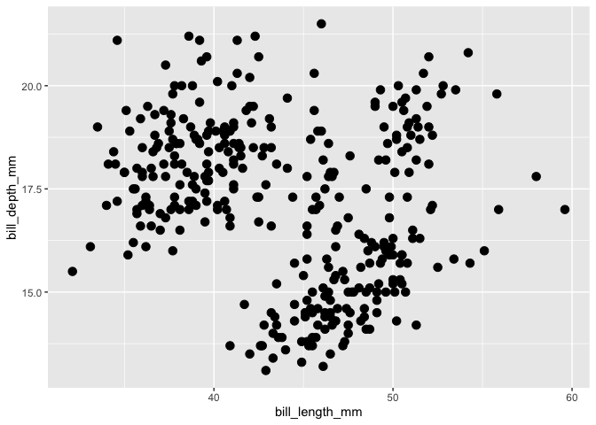

```r
ggplot(penguins, aes(x=  bill_length_mm, y= bill_depth_mm)) +
  geom_point(size = 3, shape = 19)
```

## Pregunta 2

Partiendo del gráfico anterior y usando un código similar, modifica el gráfico de dispersión para colorear los puntos por species.

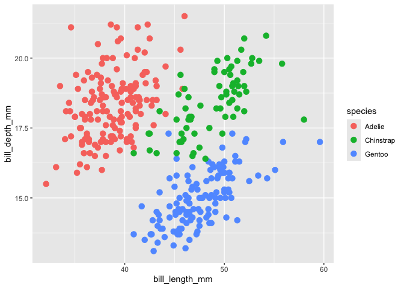

```r
ggplot(penguins, aes(x=  bill_length_mm, y= bill_depth_mm, color =species)) +
  geom_point(size = 3, shape = 19)
```

## Pregunta 3

Partiendo del gráfico anterior y usando un código similar, modifica el gráfico de dispersión para crear paneles separados por species.

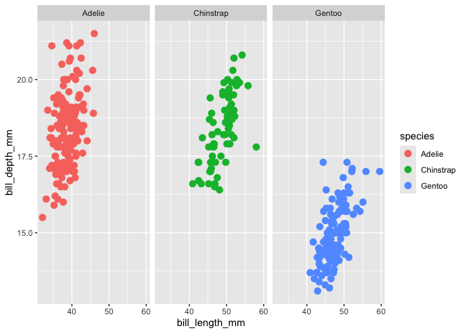

```r
ggplot(penguins, aes(x=  bill_length_mm, y= bill_depth_mm, color =species)) +
  geom_point(size = 3, shape = 19) +
  facet_wrap(~ species)
```

## Pregunta 4

Partiendo del gráfico anterior y usando un código similar, añade una línea de suavizado para cada especie.

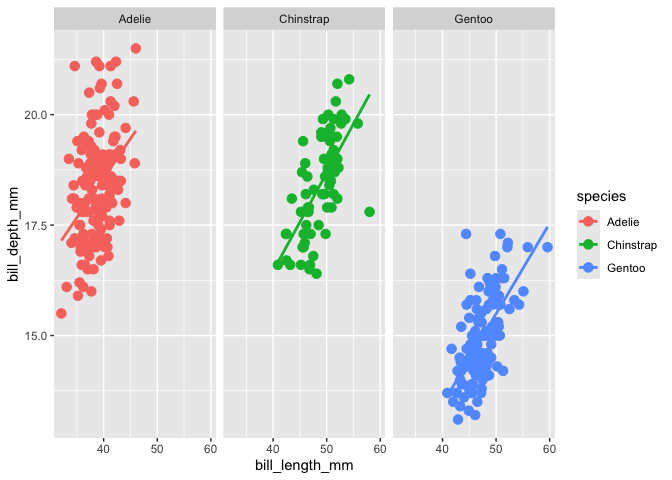

```r
ggplot(penguins, aes(x=  bill_length_mm, y= bill_depth_mm, color =species)) +
  geom_point(size = 3, shape = 19) +
  facet_wrap(~ species) +
  geom_smooth(method = "lm", se = FALSE)
```

## Pregunta 5

Partiendo del gráfico que creaste en la Pregunta 1, modifícalo para que sea apto para publicación mejorando al menos tres aspectos.

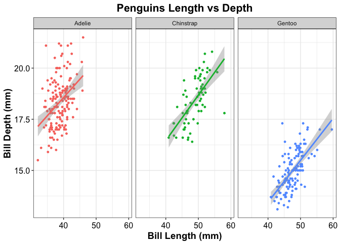

```r
ggplot(penguins, aes(x=  bill_length_mm, y= bill_depth_mm, color =species)) +
  geom_point(size = 1, shape = 19) +
   theme_bw() +
  theme(legend.position = "none") +
 labs(title = "Penguins Length vs Depth",
       x = "Bill Length (mm)",
       y = "Bill Depth (mm)") +
  facet_wrap(~ species) +
  geom_smooth(method = "lm",
              scales="free") +
  theme(plot.title = element_text(hjust=0.5, face = "bold", size = 16)) +
   theme(axis.text.x  = element_text(size = 12, vjust = 0.5, color = "black"),
        axis.text.y  = element_text(size = 12, vjust = 0.5, color = "black"),
        axis.title.x = element_text(size = 14, vjust = 0.25, face = "bold", color = "black"),
        axis.title.y = element_text(size = 14, vjust = 1,    face = "bold", color = "black"))
```

## Pregunta 6

```r
mod <- lm(body_mass_g ~ flipper_length_mm, data =
            penguins)
summary(mod)
```

```
##
## Call:
## lm(formula = body_mass_g ~ flipper_length_mm, data = penguins)
##
## Residuals:
##      Min       1Q   Median       3Q      Max
## -1058.80  -259.27   -26.88   247.33  1288.69
##
## Coefficients:
##                    Estimate Std. Error t value Pr(>|t|)
## (Intercept)       -5780.831    305.815  -18.90   <2e-16 ***
## flipper_length_mm    49.686      1.518   32.72   <2e-16 ***
## ---
## Signif. codes:  0 '***' 0.001 '**' 0.01 '*' 0.05 '.' 0.1 ' ' 1
##
## Residual standard error: 394.3 on 340 degrees of freedom
##   (2 observations deleted due to missingness)
## Multiple R-squared:  0.759,  Adjusted R-squared:  0.7583
## F-statistic:  1071 on 1 and 340 DF,  p-value: < 2.2e-16
```